# MD-HT1

### 5.3 Existe alguna relacion entre que exista un video promocional de la pelicula y la popularidad que esta alcanza?

```r
# Calcular la correlación entre la existencia de un video promocional y la popularidad
correlation <- cor(datos$video, datos$popularity)
correlation
```

```
## [1] NA
```

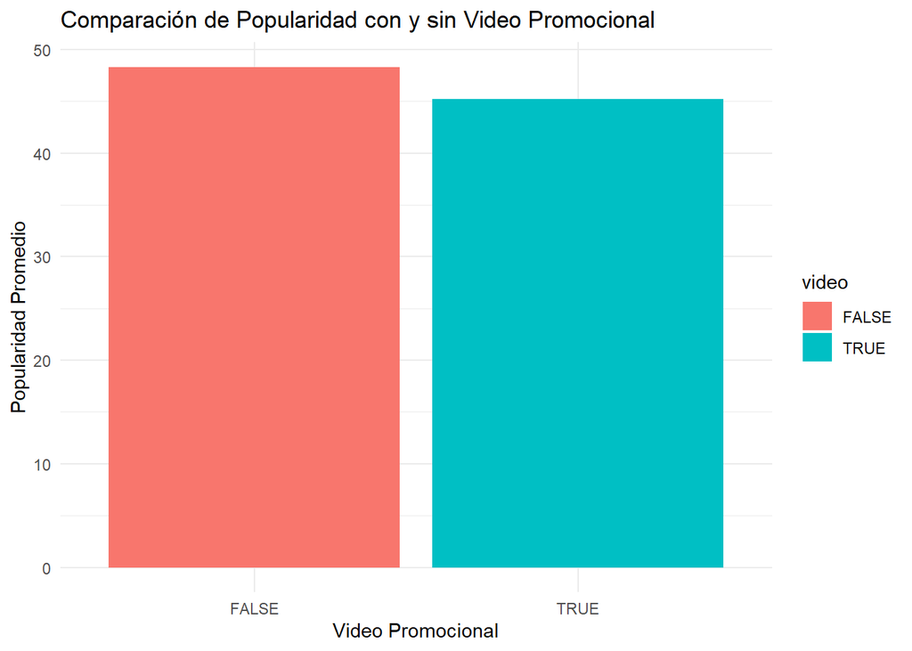

```r
# Calcular la media de popularidad para películas con y sin video promocional
mean_popularity <- aggregate(popularity ~ video, data = datos, FUN = mean)

# Crear un gráfico de barras para comparar la popularidad entre películas con y sin video promocional
ggplot(mean_popularity, aes(x = video, y = popularity, fill = video)) +
  geom_bar(stat = "identity") +
  labs(title = "Comparación de Popularidad con y sin Video Promocional",
       x = "Video Promocional",
       y = "Popularidad Promedio") +
  theme_minimal()
```

### 5.4 ¿Cuál es la proporción de películas según la cantidad de géneros que posee? ¿Y cuál es la que más tiene?

```r
# Seleccionar las primeras 15 filas con los campos 'title', 'revenue', 'voteAvg'
top_10_revenue <- head(datos[order(-datos$genresAmount), c("title", "genresAmount")], 1)
print(top_10_revenue)
```

```
##                                             title genresAmount
## 9656 Live Spectacle NARUTO ~Song of the Akatsuki~           16
```

La película que más géneros tiene es Live Spectale NARUTO -Song of the Akatsuki- con un total de 16 géneros

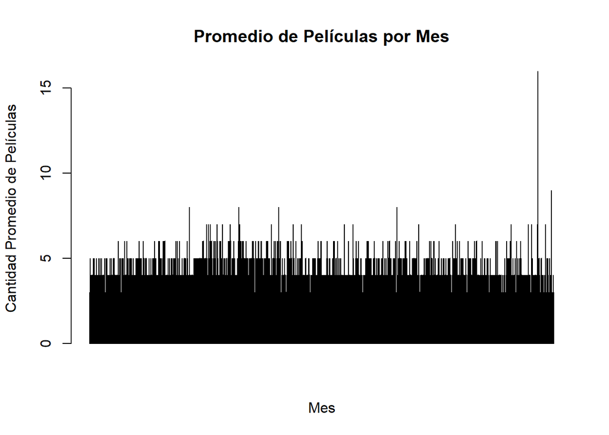

```r
datos <- read.csv("movies.csv")

# Crear gráfico de barras
barplot(datos$genresAmount, main = "Promedio de Películas por Mes", xlab = "Mes", ylab = "Cantidad Promedio de Películas")
```

En el gráfico se puede observar la generalidad de cantidad de génerospor película, el dato que sobresale es el máximo anteriormente expuesto “Live Spectale NARUTO -Song of the Akatsuki-”, las demás permanecen dentro de un rango promedio entre 3 y 7 géneros.

### 5.5 ¿Existe algun tipo de relación entre el presupuesto y la cantidad de países de grabación?

```r
# Convertir las columnas productionCountriesAmount y budget a formato numérico
datos$actorsAmount <- as.numeric(datos$productionCountriesAmount)
datos$runtime <- as.numeric(datos$budget)

# Excluir filas con valores de 0 o NA
datos_filtrados <- subset(datos, productionCountriesAmount != 0 & budget != 0 & !is.na(productionCountriesAmount) & !is.na(budget))

# Calcular la correlación entre productionCountriesAmount y budget en los datos filtrados
correlation <- cor(datos_filtrados$productionCountriesAmount, datos_filtrados$budget)
correlation
```

```
## [1] -0.00342393
```

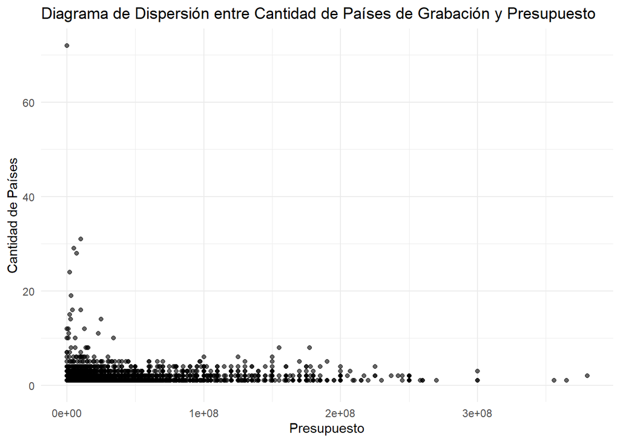

```r
# Diagrama de dispersión entre productionCountriesAmount y budget en los datos filtrados
ggplot(datos_filtrados, aes(x = budget, y = productionCountriesAmount)) +
  geom_point(alpha = 0.6) +
  labs(title = "Diagrama de Dispersión entre Cantidad de Países de Grabación y Presupuesto",
       label = paste("Correlación:", round(correlation, 2)),
       x = "Presupuesto",
       y = "Cantidad de Países") +
  scale_y_continuous(limits = c(0, max(datos_filtrados$productionCountriesAmount))) +
  theme_minimal()
```

No existe ningún tipo de relación entre el presupuesto y la cantidad de países de grabación, esto se ve corroborado por nuestro índice y el gráfico generado. Este último demuestra incluso que las pelícunas grabadas en una mayor cantidad de países no poseían un presupuesto demasiado grande en comparación a otras películas.

### 5.6 ¿Cuántas películas se han grabado para cada idioma?

```r
# Contabilizar películas y agruparlas según su idioma original
frecuencia_idiomas <- table(datos$originalLanguage)

print(frecuencia_idiomas)
```

```
##
##   ar   bn   ca   cn   cs   da   de   el   en   es   eu   fa   fi   fr   he   hi
##    1    1    1   80    2   27   84    2 7772  425    1    3    8  271    1   27
##   id   is   it   ja   ko   la   ml   ms   nb   nl   no   pl   pt   ro   ru   sr
##   12    4  100  644  167    1    1    1    1   18   28   15   43    2   67    4
##   sv   ta   te   th   tl   tr   uk   zh
##   27    1    5   17    5   10    2  119
```

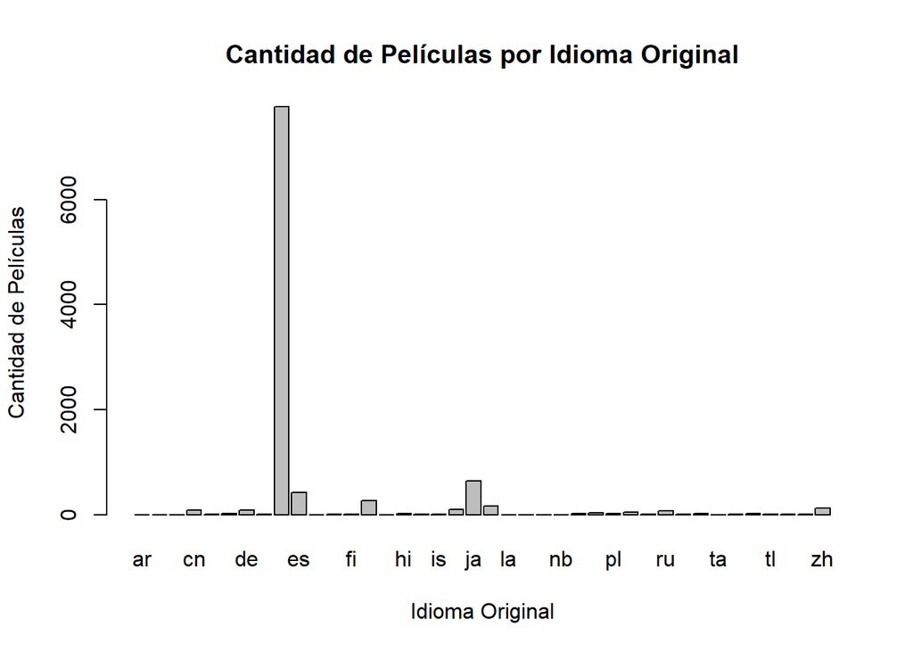

```r
# Generar el gráfico de barras
barplot(frecuencia_idiomas,
        main = "Cantidad de Películas por Idioma Original",
        xlab = "Idioma Original",
        ylab = "Cantidad de Películas")
```

Cómo se puede observar en la gráfica de barras generada, el idioma original con más cantidad de películas es el inglés con un total de 7772 películas, seguido del japonés con 644 películas, y del español con 425 películas respectivamente.